# San Juan escapement 2025 (PRELIM)

# 5 **Pink**

## 5.1 Area 20 raw vs expanded counts

Counts are expanded for % population estimated and/or observer efficiency, depending on survey conditions.

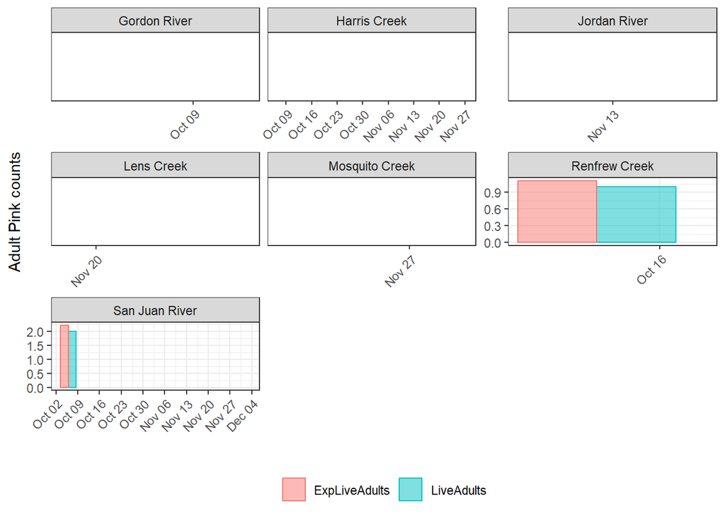

Figure: Observed adult Pink counts (blue) and expanded for OE/%habitat (pink).

## 5.2 Swim & fence counts

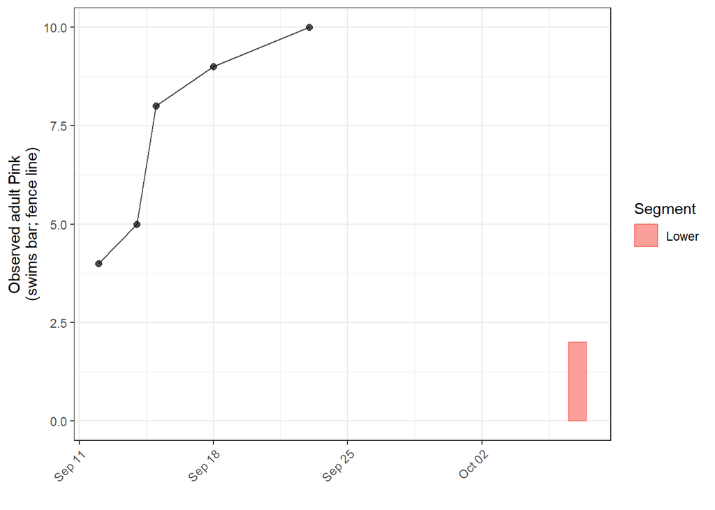

Figure: Pink swim counts (raw adults) in the San Juan mainstem relative to cumulative fence counts (black line). If no black line, then no pink were counted through the fence this year.

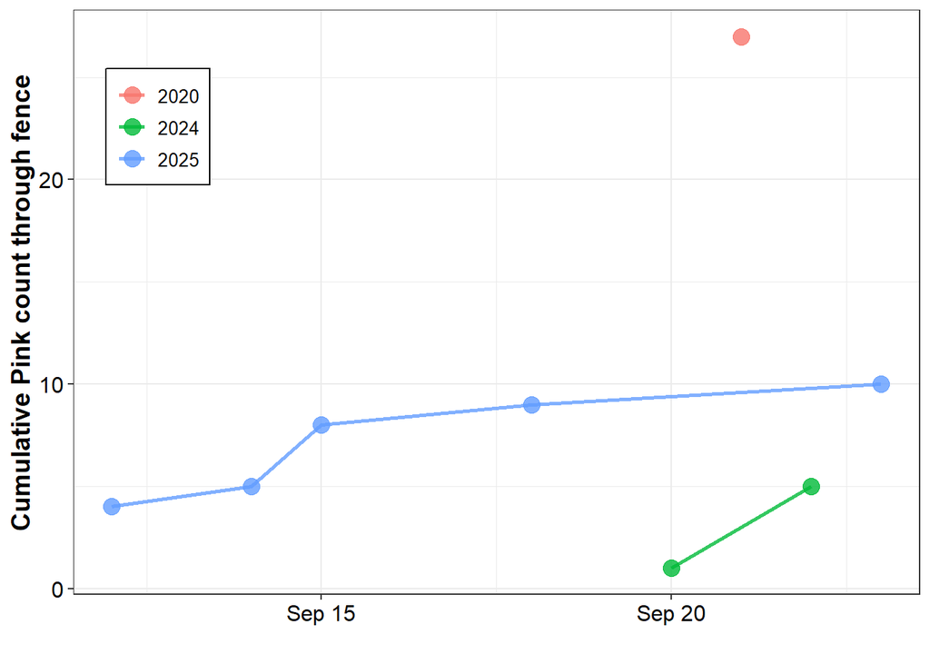

Figure: Cumulative fence counts for Pinks over time. Fence operated by 4 Mile hatchery with install date usually just after Labour day and removal around Thanksgiving.

## 5.3 Tributaries

| trib_status | system | date | expanded_live_adults | dead_adults |
| --- | --- | --- | --- | --- |
| SJ trib | Renfrew | 2025-10-14 | 1 | 0 |

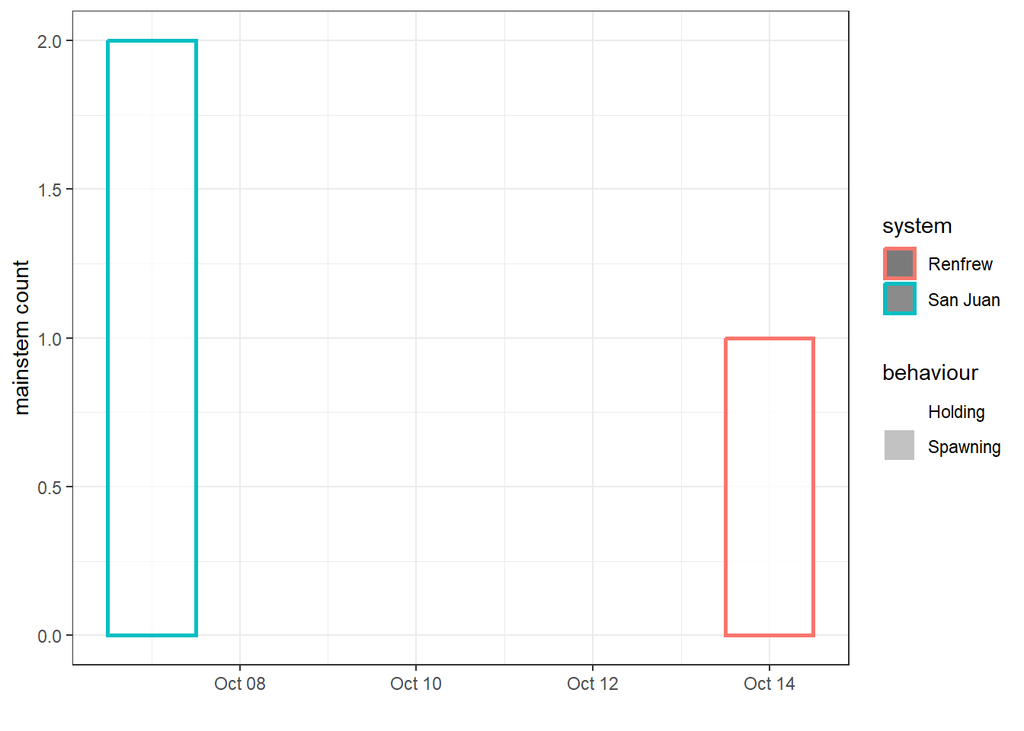

## 5.4 Area 20 preliminary escapement estimate (PL+D)

Table: San Juan swim counts (expanded live and dead) and preliminary escapement estimates for San Juan surveys.

| ShortSpecies | Section_AreaInspected | SDate | WaterTemperature | WaterClarity | LiveAdults | DeadAdults | LiveJacks | DeadJacks | ExpLiveAdults | ExpDeadAdults | ExpLiveJacks | ExpDeadJacks | OverallReliability | EstPctSeen |
| --- | --- | --- | --- | --- | --- | --- | --- | --- | --- | --- | --- | --- | --- | --- |
| PK | FAIRY CREEK | 2025-11-25 | 99.0 | NA | NA | NA | NA | NA | NA | NA | NA | NA | NA | NA |
|  | FALLS CREEK | 2025-11-26 |  | NA | NA | NA | NA | NA | NA | NA | NA | NA | NA | NA |
|  | GORDON RIVER | 2025-10-08 | 9.5 | 3 - 5 m or to Bottom | NA | NA | NA | NA | NA | NA | NA | NA | NA | NA |
|  | HARRIS CREEK | 2025-10-09 | 11.5 | 3 - 5 m or to Bottom | NA | NA | NA | NA | NA | NA | NA | NA | NA | NA |
|  |  | 2025-11-25 | 99.0 | NA | NA | NA | NA | NA | NA | NA | NA | NA | NA | NA |
|  | JORDAN RIVER | 2025-11-13 | 9.0 | 3 - 5 m or to Bottom | NA | NA | NA | NA | NA | NA | NA | NA | NA | NA |
|  | LENS CREEK | 2025-11-21 | 8.0 | 3 - 5 m or to Bottom | NA | NA | NA | NA | NA | NA | NA | NA | NA | NA |
|  |  | 2025-11-24 | 99.0 | NA | NA | NA | NA | NA | NA | NA | NA | NA | NA | NA |
|  | MOSQUITO CREEK | 2025-11-26 |  | NA | NA | NA | NA | NA | NA | NA | NA | NA | NA | NA |
|  | RENFREW CREEK | 2025-10-14 | 9.0 | 3 - 5 m or to Bottom | 1 | NA | NA | NA | 1 | NA | NA | NA | H | 1 |
|  |  | 2025-10-15 |  | 3 - 5 m or to Bottom | NA | NA | NA | NA | NA | NA | NA | NA | NA | NA |
|  | SAN JUAN RIVER | 2025-10-06 | 10.0 | 3 - 5 m or to Bottom | NA | NA | NA | NA | NA | NA | NA | NA | H | 1 |
|  |  | 2025-10-07 | 10.5 | 3 - 5 m or to Bottom | 2 | 0 | NA | NA | 2 | NA | NA | NA | H | 1 |
|  |  | 2025-10-16 | 6.0 | 3 - 5 m or to Bottom | NA | NA | NA | NA | NA | NA | NA | NA | NA | NA |
|  |  | 2025-10-17 | 10.5 | 3 - 5 m or to Bottom | NA | NA | NA | NA | NA | NA | NA | NA | NA | NA |
|  |  | 2025-12-01 | 4.0 | 3 - 5 m or to Bottom | NA | NA | NA | NA | NA | NA | NA | NA | NA | NA |
|  |  | 2025-12-03 | 4.5 | 3 - 5 m or to Bottom | NA | NA | NA | NA | NA | NA | NA | NA | NA | NA |

Table: Escapement estimates for each system. San Juan mainstem surveys were rolled up based on mid-point date for each of 3 complete survey events, and then the PL+D was selected based on the 3 survey events.

| ShortSpecies | SystemName | AdultRawPLD | AdultExpPLD | JackRawPLD | JackExpPLD | AdultRemovalsReco | JackRemovalsReco | FinalAdultEstimate | FinalJackEstimate |
| --- | --- | --- | --- | --- | --- | --- | --- | --- | --- |
| PK | Jordan River | 0 | 0 | 0 | 0 | 0 | 0 | 0 | 0 |
|  | San Juan River | 2 | 2 | 0 | 0 | 0 | 0 | 10 | 0 |
|  | Falls Creek | 0 | 0 | 0 | 0 | 0 | 0 | 0 | 0 |
|  | Mosquito Creek |  |  | 0 | 0 | 0 | 0 | 0 | 0 |
|  | Fairy Creek |  |  | 0 | 0 | 0 | 0 | 0 | 0 |
|  | Renfrew Creek | 1 | 1 | 0 | 0 | 0 | 0 | 1 | 0 |
|  | Harris Creek | 0 | 0 | 0 | 0 | 0 | 0 | 0 | 0 |
|  | Lens Creek |  |  | 0 | 0 | 0 | 0 | 0 | 0 |
|  | Gordon River |  |  | 0 | 0 | 0 | 0 | 0 | 0 |

### 5.4.1 Estimate decision:

Fence count higher than swims so used fence count for SJ.

## 5.5 2025 compared to historical abundance

[figure not shown]

Figure: 2025 preliminary adult Pink escapement estimate (red outline) relative to historical adult (blue) and unspecified (gray) escapement estimates. Gaps indicate years without estimates.